# Education and Hygiene: Cornerstones for Child Development

### Limitations of the Analysis:

- **Incomplete Data**: The time-series data may contain gaps or missing values for certain years or countries, which can affect the interpretation of trends. The lack of consistent data from some countries may limit the overall analysis of global sanitation progress.
- **Contextual Factors**: While the time-series plot offers a useful snapshot of trends, it is important to remember that **external factors**, such as **economic conditions**, **political stability**, and **social norms**, play a significant role in shaping these trends. These factors may not be fully captured in the data but are crucial to understanding the reasons behind the trends.

In conclusion, the time-series plot provides a comprehensive overview of how hygiene access has evolved over time in key countries. It highlights the successes and challenges faced by countries in improving sanitation and serves as a powerful tool for assessing the effectiveness of global and national policies aimed at achieving universal sanitation access.

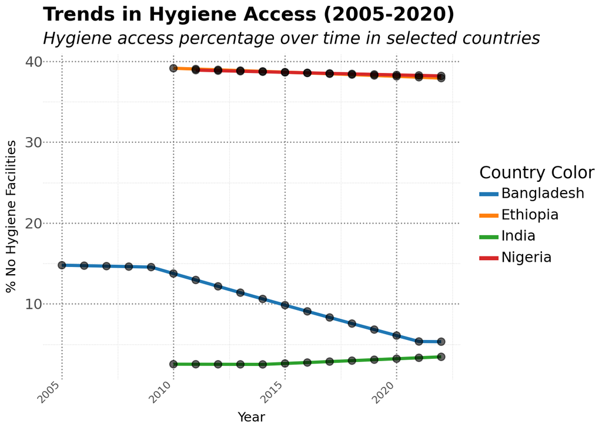

```python
import pandas as pd
import plotnine as p9

# List of key countries
key_countries = ["India", "Nigeria", "Brazil", "Ethiopia", "Bangladesh"]

# Filter data for key countries and sex = 'Total'
ts = indicator2[(indicator2['country'].isin(key_countries)) & (indicator2['sex'] == 'Total')]

# Plot
(p9.ggplot(ts, p9.aes(x='time_period', y='obs_value', color='country', group='country')) +
    p9.geom_line(size=1.5, show_legend=True) +  # Different line types for each country
    p9.geom_point(size=3, shape='o', color='black', alpha=0.6) +  # Add points for each data point
    p9.scale_color_manual(values=['#1f77b4', '#ff7f0e', '#2ca02c', '#d62728', '#9467bd']) +  # Custom color palette
    p9.scale_linetype_manual(values=['solid', 'dashed', 'dotted', 'dotdash', 'longdash']) +  # Different line types for each country
    p9.labs(
        title='Trends in Hygiene Access (2005-2020)',
        subtitle='Hygiene access percentage over time in selected countries',  # Add subtitle for context
        x='Year',
        y='% No Hygiene Facilities',
        color='Country',
        linetype='Country'  # Legend for linetype and color
    ) +
    p9.theme_minimal() +
    p9.theme(
        axis_text_x=p9.element_text(rotation=45, hjust=1),  # Rotate x-axis labels for better readability
        axis_text_y=p9.element_text(size=12),  # Increase font size for y-axis labels
        plot_title=p9.element_text(size=16, weight='bold'),  # Make the title bolder
        plot_subtitle=p9.element_text(size=14, style='italic'),  # Subtitle in italics
        legend_title=p9.element_text(size=14),  # Legend title font size
        legend_text=p9.element_text(size=12),  # Legend text font size
        panel_grid_major=p9.element_line(color='gray', linetype='dotted'),  # Light grid lines
        panel_grid_minor=p9.element_line(color='lightgray', linetype='dotted')  # Lighter grid lines
    ) +
    p9.guides(
        linetype=p9.guide_legend(title="Country Line Type"),  # Customize legend title for line type
        color=p9.guide_legend(title="Country Color")  # Customize legend title for color
    )
)
```